# Relative fitness in a field setting - Figure 4 (Evolution MS)

Miranda Melen

December 2022

#Background At Blue Oak Ranch Reserve, we established a 10m x 26m fenced field site to test whether evolution over the course of invasion away from roads has resulted in enhanced performance in undisturbed vegetation relative to roadside populations. The experiment was replicated in a randomized block design (20 plots in total). Each plot was 1.5m2 with 16 D. graveolens growing in a 4 x 4 grid centered on the plot. There was 33cm between each plant and 25cm between the edge plants and the border of the plot.

The experiment included multiple treatments; however, only the two most relevant to the focus of this paper are included here. We tested whether plant genotypes collected from the two habitats (roadside and vegetated) responded differently to the disturbance of biomass removal. We tilled in December 2020 to completely remove below and aboveground biomass, and then weeded to remove aboveground biomass throughout the growing season. In contrast, we left the control plots untouched, allowing the previous year’s thatch to persist and background vegetation to grow throughout the experiment.

In January 2021, we germinated seeds in Petri dishes at the UCSC Coastal Science Campus greenhouse incubation chambers before transplanting them into field-collected soil (collected in late December 2020 from Blue Oak Ranch Reserve). Seedlings grew in the greenhouse for about eight weeks until all plants had their first two true leaves emerge and lengthen. Ideally, we would have placed seeds directly into the field, but to maximize biosafety, we used seedling transplants that could be tracked with 100% certainty.

We measured the longest leaf for each plant and then transplanted them into the ground in late February 2021 at Blue Oak Ranch Reserve. During the first month of growth, we replaced any D. graveolens that died. We conducted weekly phenology surveys to assess D. graveolens plant health, and at the first sign of buds, we measured plant height and harvested the aboveground biomass by cutting at the root crown and drying in a 60ºC oven for 3 days before weighing.

#Data Analysis Statistical analyses were performed in R version 4.2.1 (R Core Team 2022) using linear mixed-effects models with the lme4 (Bates et al. 2015), lmerTest (Kuznetsova et al. 2017), and DHARMa packages (Hartig 2022), generalized linear mixed models with the glmmTMB package (Brooks et al. 2017), and mixed effects cox models with the coxme (Therneau 2022a) and survival (Therneau 2022b) packages.

#Libraries

```r
#install.packages("coxme")
#install.packages("survival")
#install.packages("ggplot2")
#install.packages("ggfortify")
#install.packages("car")
#install.packages("multcomp")
#install.packages("lme4")
#install.packages("lmerTest")
#install.packages("DHARMa")
#install.packages("dplyr")
#install.packages("emmeans")
#install.packages('TMB', type = 'source')
#install.packages("glmmTMB")
#install.packages("MASS")
#install.packages("emmeans")
#install.packages("AICcmodavg")
library(coxme)
library(survival)
library(ggplot2)
library(ggfortify)
library(car)
library(multcomp)
library(lme4)
library(lmerTest)
library(DHARMa)
library(dplyr)
library(emmeans)
library(TMB)
library(glmmTMB)
library(MASS)
library(emmeans)
library(AICcmodavg)
library(tidyverse)
```

#Load Data This dataframe has one row per plant (320 observations). Data are for survivorship curves (3 censor options), the number of days the plant stayed alive (NumDaysAlive) and aboveground biomass. Censors with a 1 denote reaching the event (CensorAll = died, CensorBiomass = survived to collect biomass, CensorReproduction = survived to reproduce) and a 0 denoting when a seed didn’t germinate by the last census date (Census = 11/15/21). CensorReproduction will be most useful in understanding the amount of biomass produced by an individual when buds appear.

```r
mydata<-read.csv("/Users/Miranda/Documents/Education/UC Santa Cruz/Dittrichia/Dittrichia_Analysis/data/field_relative_fitness/MS_Evolution_Fig4_2021.csv",stringsAsFactors=T)
str(mydata) #Check that each column has the right class (factor, integer, numeric, etc.)
```

```
'data.frame':   320 obs. of  31 variables:
 $ Block             : Factor w/ 10 levels "A","B","C","D",..: 1 2 3 4 5 6 7 8 9 10 ...
 $ Plot              : int  5 2 2 1 5 1 1 4 4 2 ...
 $ Flag              : Factor w/ 20 levels "A2","A5","B1",..: 2 4 5 7 10 11 13 16 17 19 ...
 $ Pos               : int  3 15 13 13 6 10 8 4 12 3 ...
 $ Flag_Pos          : Factor w/ 320 levels "A2_01","A2_02",..: 19 63 77 109 150 170 200 244 268 291 ...
 $ Population        : Factor w/ 16 levels "BAY-A","BAY-O",..: 1 1 1 1 1 1 1 1 1 1 ...
 $ Site              : Factor w/ 8 levels "BAY","CHE","GUA",..: 1 1 1 1 1 1 1 1 1 1 ...
 $ Habitat           : Factor w/ 2 levels "Roadside","Vegetated": 1 1 1 1 1 1 1 1 1 1 ...
 $ Treatment         : Factor w/ 2 levels "Biomass Removal",..: 1 1 1 1 1 1 1 1 1 1 ...
 $ HabitatTreatment  : Factor w/ 4 levels "Roadside/Biomass Removal",..: 1 1 1 1 1 1 1 1 1 1 ...
 $ PlantDate         : Factor w/ 7 levels "2/27/21","3/1/21",..: 5 1 1 1 1 1 7 1 1 1 ...
 $ LeafMeas1         : num  30 20.3 27 14.9 16.7 ...
 $ LeafMeas2         : int  46 51 NA 56 42 45 36 58 52 45 ...
 $ Growth            : num  16 30.7 -27 41 25.3 ...
```

[output cut: 17 more lines]

```r
mydata$Site<-as.character(mydata$Site)
mydata$Treatment<-factor(mydata$Treatment,
                         levels=c("Grassland","Biomass Removal")) #Changing the contrast order so that everything is compared to Grassland (control)
```

Note: 10 blocks, 2 treatments, 16 populations (CHE-O), 8 sites (random: population pairs; CHE), 2 habitat (fixed effect: roadside and vegetated; R or O)

Also Note: Growth data is a measure of growth of longest leaf. Each plant was measured upon transplanting into the field in March and then again in May 2021. This plant has a juvenile stage of a basal rosette, and then it bolts and produced smaller cauline leaves. The goal was to capture early growth data for this plant before bolting occurs so that the measurements capture the basal rosette stage, however in some cases the plants bolted earlier than expected and the resulting measurement was smaller than previous. In these cases we determined that the data should be removed from the dataset as the negative number (or changing it to a zero) does not reflect the biological importance of the measurement.

```r
growth_mydata<-mydata%>%filter(Growth>0) #Here I am only looking at the Growth data that is greater than 0 (see Also Note above)
growth_mydata$PlantDate<-as.Date(growth_mydata$PlantDate,"%m/%d/%y")

growth_mydata$Num.Days.Growth<-as.Date("2021-05-22")-growth_mydata$PlantDate #number days
growth_mydata$Num.Days.Growth<-as.numeric(growth_mydata$Num.Days.Growth)
growth_mydata$Growth.Rate<-growth_mydata$Growth/growth_mydata$Num.Days.Growth #First calculate number of days of growth to get the Rate
```

##Histograms ###Original data When we plot the original data as a histogram, we find that it is skewed. We also use the Shapiro-Wilk normality test, but get a p-value = 1.402e-05.

In statistical hypothesis testing, a common significance level (alpha) is set at 0.05. If the p-value is less than alpha (p-value < alpha), it suggests strong evidence against the null hypothesis. In this case, the p-value is extremely small (less than 1.402e-05), indicating very strong evidence against the null hypothesis.

Therefore, based on the given output, it can be concluded that the dataset did not pass the Shapiro-Wilk normality test. The data is unlikely to follow a normal distribution. Let’s consider log transforming the data.

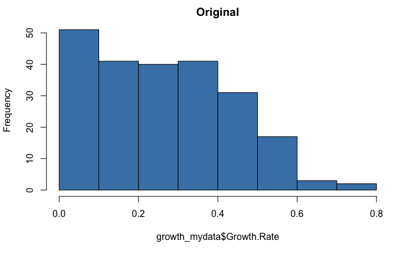

```r
hist(growth_mydata$Growth.Rate,
     col='steelblue',
     main='Original')
```

```r
shapiro.test(growth_mydata$Growth.Rate)
```

```
    Shapiro-Wilk normality test

data:  growth_mydata$Growth.Rate
W = 0.96321, p-value = 1.402e-05
```

###Log transform data (https://www.statology.org/transform-data-in-r/) When we log transform the data and plot using a histogram, the data does not look, but we need to still test for normalicy with a Shapiro-Wilk normality test. Here we find that the data are not normally distributed because the p-value = 7.398e-14.

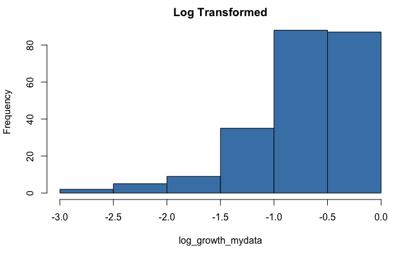

```r
log_growth_mydata<-log10(growth_mydata$Growth.Rate)
hist(log_growth_mydata,
     col='steelblue',main='Log Transformed') #Log transformed data does not look good at all!
```

```r
shapiro.test(log_growth_mydata) #Data does not improve with log transformation
```

```
    Shapiro-Wilk normality test

data:  log_growth_mydata
W = 0.85341, p-value = 7.398e-14
```

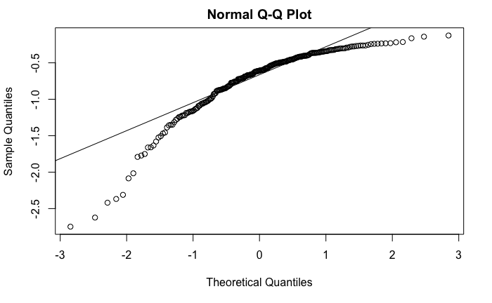

```r
qqnorm(log_growth_mydata) #qqplot
qqline(log_growth_mydata) #add the line
```

###Square root transform data This improved the distribution, but it failed the Shapiro-Wilk normality test (p-value = 0.001034). Let’s try poisson.

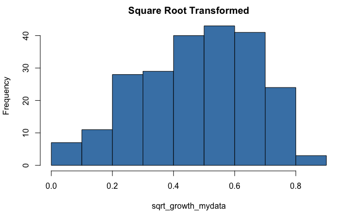

```r
sqrt_growth_mydata<-sqrt(growth_mydata$Growth.Rate)
hist(sqrt_growth_mydata,
     col='steelblue',main='Square Root Transformed') #Square root transformed data looks better than the original distribution
```

```r
shapiro.test(sqrt_growth_mydata)
```

```
    Shapiro-Wilk normality test

data:  sqrt_growth_mydata
W = 0.97721, p-value = 0.001034
```

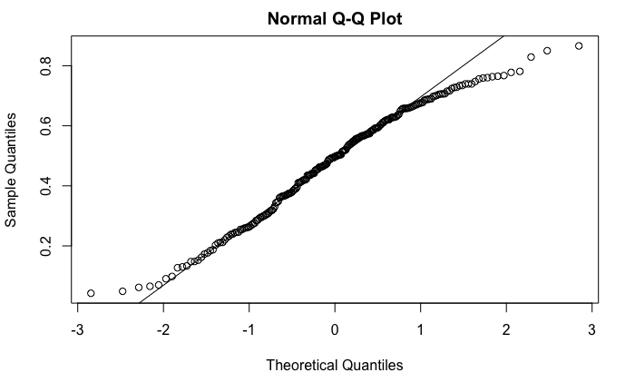

```r
qqnorm(sqrt_growth_mydata) #qqplot
qqline(sqrt_growth_mydata) #add the line
```

###Poisson distribution Poisson is actually not a good fit because the growth rate is not an integer (has decimals), which poisson is not equipt to deal with. Maybe I’ll try gamma?

```r
library(MASS)
MASS::fitdistr((growth_mydata$Growth.Rate*1000),
               "Poisson")
```

```
     lambda
  264.890459
 (  1.082627)
```

```
[1] 40 81
```

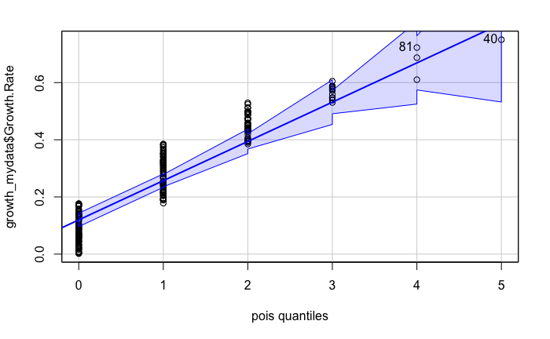

```r
qqPlot(growth_mydata$Growth.Rate,
       distribution="pois",
       lambda=1)
```

###Gamma distribution Nope, not gamma

```
[1] 40 81
```

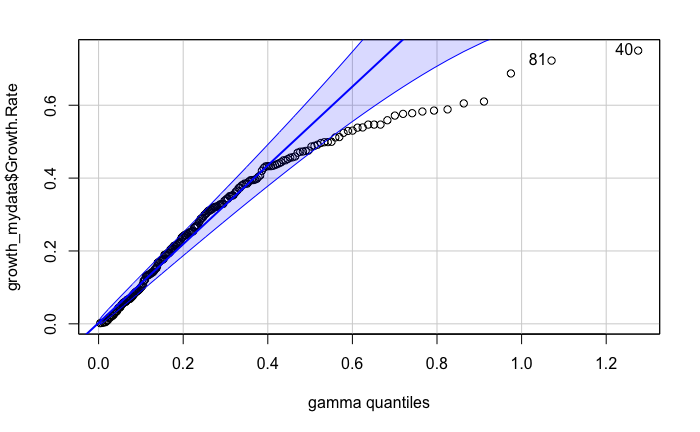

```r
gamma<-fitdistr(growth_mydata$Growth.Rate,
                "gamma")
qqp(growth_mydata$Growth.Rate,
    "gamma",
    shape=gamma$estimate[[1]],
    rate=gamma$estimate[[2]])
```

##Models ###Full Model 1 - glmm

```r
growth_fullmodel1<-glmmTMB(Growth.Rate~
                             Habitat*Treatment+
                             (1|Site)+
                             (1|Block),
                           family=Gamma(link="log"),
                           data=growth_mydata)
summary(growth_fullmodel1)
```

```
 Family: Gamma  ( log )
Formula:          Growth.Rate ~ Habitat * Treatment + (1 | Site) + (1 | Block)
Data: growth_mydata

     AIC      BIC   logLik deviance df.resid
  -285.7   -261.8    149.9   -299.7      219

Random effects:

Conditional model:
 Groups Name        Variance  Std.Dev.
 Site   (Intercept) 0.0008935 0.02989
 Block  (Intercept) 0.0116777 0.10806
Number of obs: 226, groups:  Site, 8; Block, 10

Dispersion estimate for Gamma family (sigma^2): 0.392

Conditional model:
                                          Estimate Std. Error z value Pr(>|z|)
(Intercept)                               -2.38870    0.11451 -20.860   <2e-16 ***
HabitatVegetated                           0.14981    0.14068   1.065    0.287
TreatmentBiomass Removal                   1.32254    0.13255   9.977   <2e-16 ***
HabitatVegetated:TreatmentBiomass Removal -0.09731    0.17488  -0.556    0.578
---
Signif. codes:  0 ‘***’ 0.001 ‘**’ 0.01 ‘*’ 0.05 ‘.’ 0.1 ‘ ’ 1
```